# Learning Group Project H

Jingtong Dou

4/23/2019

## Description

A researcher at the University of South Carolina was interested in exploring the effects of socioeconomic status (SES) on education. SES encompasses not just income but also educational attainment, financial security, and subjective perceptions of social status and social capital. The study used the hsb2 dataset of two hundred observations randomly sampled from the 2005 High School and Beyond survey, a national survey of high school seniors. The research question is: How do school type and socioeconomic status relate to students’ reading scores?

# Analysis

First, let us prepare the data set.

```r
library(tidyverse)
hsb2 <- read_csv("hsb2.csv")
# Change school type, SES to factors.
hsb2$ses <-factor(hsb2$ses, labels = c("low", "middle", "high"))
hsb2$schtyp <- factor(hsb2$schtyp, labels = c("public", "private"))
```

Next, I’ll draw two graphs. I want to see the differences of students reading scores among school types by SES.

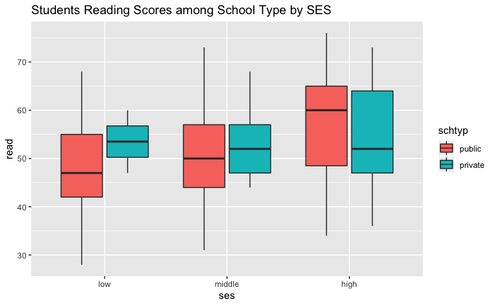

```r
ggplot(hsb2, aes(ses, read, fill= schtyp))+
  geom_boxplot() +
  labs(title = "Students Reading Scores among School Type by SES")
```

Here’ the five-number summary. Let’s caculate the mean and sd.

```r
tapply(hsb2$read, hsb2$ses, mean)
```

```
     low   middle     high
48.27660 51.57895 56.50000
```

```r
tapply(hsb2$read, hsb2$ses, sd)
```

```
      low    middle      high
 9.342987  9.425609 10.858338
```

```r
tapply(hsb2$read, hsb2$schtyp, mean)
```

```
  public  private
51.84524 54.25000
```

```r
tapply(hsb2$read, hsb2$schtyp, sd)
```

```
   public   private
10.422792  9.196774
```

Then, I conducted a model for possible interaction between SES and the school type.

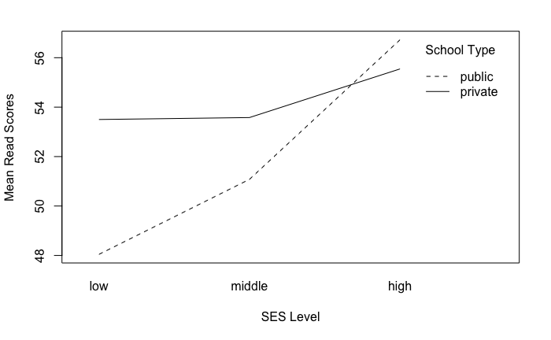

```r
# interaction.plot
interaction.plot(hsb2$ses,
                 hsb2$schtyp,
                 response = hsb2$read,
                 xlab = "SES Level",
                 ylab = "Mean Read Scores",
                 trace.label = "School Type")
```

I will build a model to test how reading scores vary in SES and school types.

```r
model <- aov(hsb2$read ~ hsb2$schtyp*hsb2$ses)
result <- summary(model)
result
```

```
                      Df Sum Sq Mean Sq F value   Pr(>F)
hsb2$schtyp            1    155   155.4   1.594 0.208321
hsb2$ses               2   1732   866.1   8.880 0.000204 ***
hsb2$schtyp:hsb2$ses   2    109    54.5   0.559 0.572727
Residuals            194  18923    97.5
---
Signif. codes:  0 ‘***’ 0.001 ‘**’ 0.01 ‘*’ 0.05 ‘.’ 0.1 ‘ ’ 1
```

Conduct a Post-hoc analysis

```r
TukeyHSD(aov(hsb2$read~ hsb2$ses))
```

```
  Tukey multiple comparisons of means
    95% family-wise confidence level

Fit: aov(formula = hsb2$read ~ hsb2$ses)

$`hsb2$ses`
                diff        lwr       upr     p adj
middle-low  3.302352 -0.8430804  7.447784 0.1468044
high-low    8.223404  3.6612698 12.785539 0.0000948
high-middle 4.921053  1.0475284  8.794577 0.0085237
```

# Conclusion

The researcher explored the relation between school type and SES to students’ reading scores. The sample data suggests that higher SES level is associated with higher reading scores and students in private schools tend to score higher.The interaction plot indicates the possible interaction between the SES and the school type for reading scores.The researcher then ran a two-way ANOVA to test the effects of school type and SES to students’ reading scores. The p-value for the interaction of SES and school type is 0.57, which indicates little interaction effect. Furthermore, the p-value for SES is 0.000204, which is stable enough to illustrate the SES is related to students’ reading scores, but we could not conclude which level of SES effects reading scores most. To explore even further, the researcher conducted a post-hoc analysis. The result indicates that SES level, especially students from low SES and high SES effect their reading scores most.